# TP1

## Question 3

Utiliser `cor`, `lm(science~read, data=FR2018)`, `summary(lm())`, `abline(lm())`.

```r
> cor(FR2018$science , FR2018$read)
```

```
[1] 0.8441456
```

```r
> FRscienceread <- lm(science~read , data=FR2018)
> class(FRscienceread)
```

```
[1] "lm"
```

```r
> FRscienceread
```

```
Call:
lm(formula = science ~ read, data = FR2018)

Coefficients:
(Intercept)         read
    83.4910       0.8304
```

```r
> summary(FRscienceread)
```

```
Call:
lm(formula = science ~ read, data = FR2018)

Residuals:
     Min       1Q   Median       3Q      Max
-100.863  -35.371   -0.777   27.516  119.122

Coefficients:
            Estimate Std. Error t value Pr(>|t|)
(Intercept) 83.49102   37.14473   2.248   0.0292 *
read         0.83044    0.07613  10.909 1.36e-14 ***
---
Signif. codes:  0 '***' 0.001 '**' 0.01 '*' 0.05 '.' 0.1 ' ' 1

Residual standard error: 50.36 on 48 degrees of freedom
Multiple R-squared:  0.7126,    Adjusted R-squared:  0.7066
F-statistic:   119 on 1 and 48 DF,  p-value: 1.36e-14
```

```r
> coef(summary(FRscienceread))
```

```
             Estimate  Std. Error   t value     Pr(>|t|)
(Intercept) 83.491018 37.14473083  2.247722 2.922508e-02
read         0.830442  0.07612521 10.908897 1.360018e-14
```

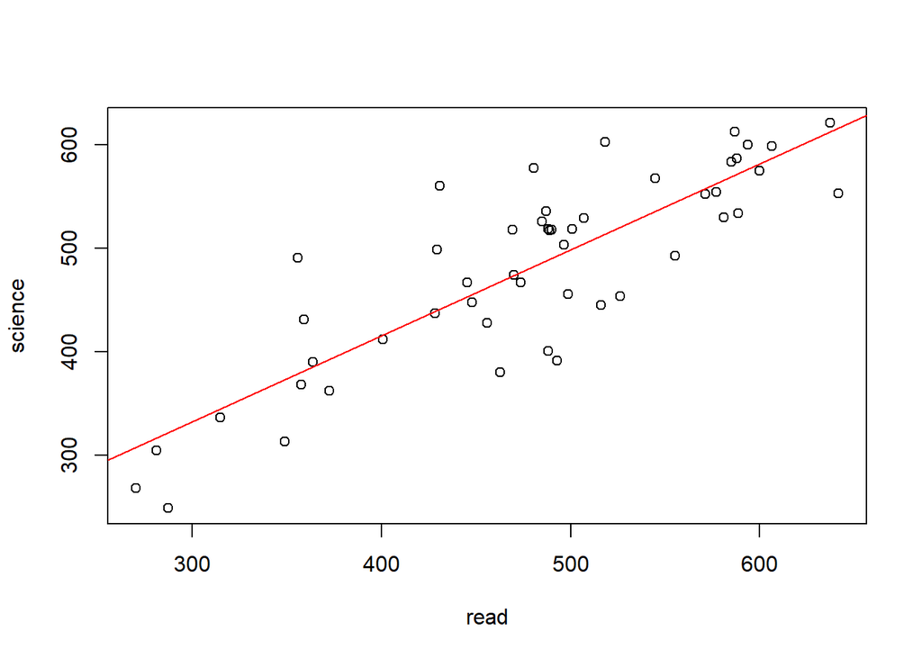

```r
> plot(science~read, data=FR2018)
> abline(FRscienceread , col="red")
```

```r
> print(FRscienceread$r.squared)
```

[output not shown]

$R^2=$ 0.7

## Question 4

## Question 5

Utiliser `cor`, `lm(math~escs, data=FR2018)`, `summary(lm())`, `abline(lm())`.

```r
> FRmathec <- lm(math~escs , data=FR2018)
> summary(FRmathec)
```

```
Call:
lm(formula = math ~ escs, data = FR2018)

Residuals:
     Min       1Q   Median       3Q      Max
-153.898  -50.026    6.887   57.798  207.124

Coefficients:
            Estimate Std. Error t value Pr(>|t|)
(Intercept)   486.91      11.43  42.613  < 2e-16 ***
escs           47.53      13.37   3.555 0.000862 ***
---
Signif. codes:  0 '***' 0.001 '**' 0.01 '*' 0.05 '.' 0.1 ' ' 1

Residual standard error: 80.75 on 48 degrees of freedom
Multiple R-squared:  0.2084,    Adjusted R-squared:  0.1919
F-statistic: 12.64 on 1 and 48 DF,  p-value: 0.0008617
```

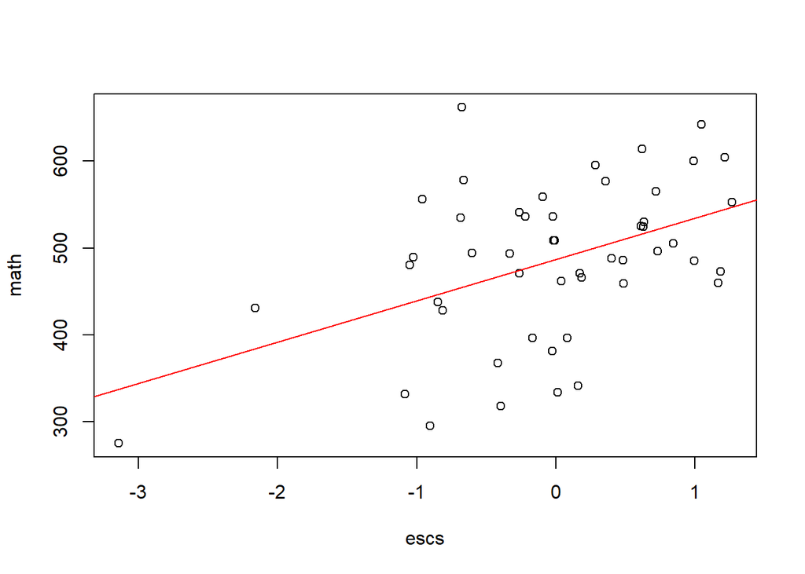

```r
> plot(math~escs , data=FR2018)
> abline(FRmathec , col="red")
```

## Question 6

Utiliser `cor`, `lm(read~escs, data=FR2018)`, `summary(lm())`, `abline(lm())`.

## Question 7

Utiliser `cor`, `lm(math~read+escs, data=FR2018)`, `summary(lm())`, `abline(lm())`.

```r
> FRmathereadescs <- lm(math~read+escs , data=FR2018)
>
> summary(FRmathereadescs)
```

```
Call:
lm(formula = math ~ read + escs, data = FR2018)

Residuals:
     Min       1Q   Median       3Q      Max
-123.719  -22.208    0.944   33.987  103.615

Coefficients:
            Estimate Std. Error t value Pr(>|t|)
(Intercept) 125.3403    40.5713   3.089  0.00336 **
read          0.7527     0.0832   9.047 7.33e-12 ***
escs         10.8129     9.1137   1.186  0.24141
---
Signif. codes:  0 '***' 0.001 '**' 0.01 '*' 0.05 '.' 0.1 ' ' 1

Residual standard error: 49.28 on 47 degrees of freedom
Multiple R-squared:  0.7112,    Adjusted R-squared:  0.6989
F-statistic: 57.88 on 2 and 47 DF,  p-value: 2.103e-13
```

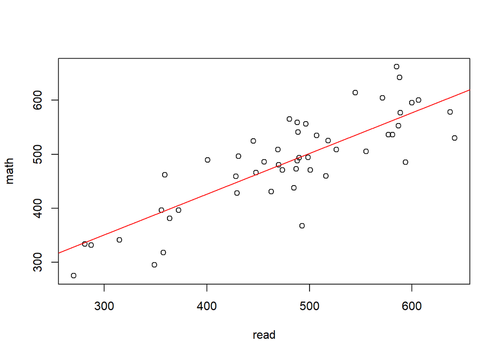

```r
> plot(math~read , data=FR2018)
> abline(coef(FRmathereadescs)[1:2] , col="red")
```

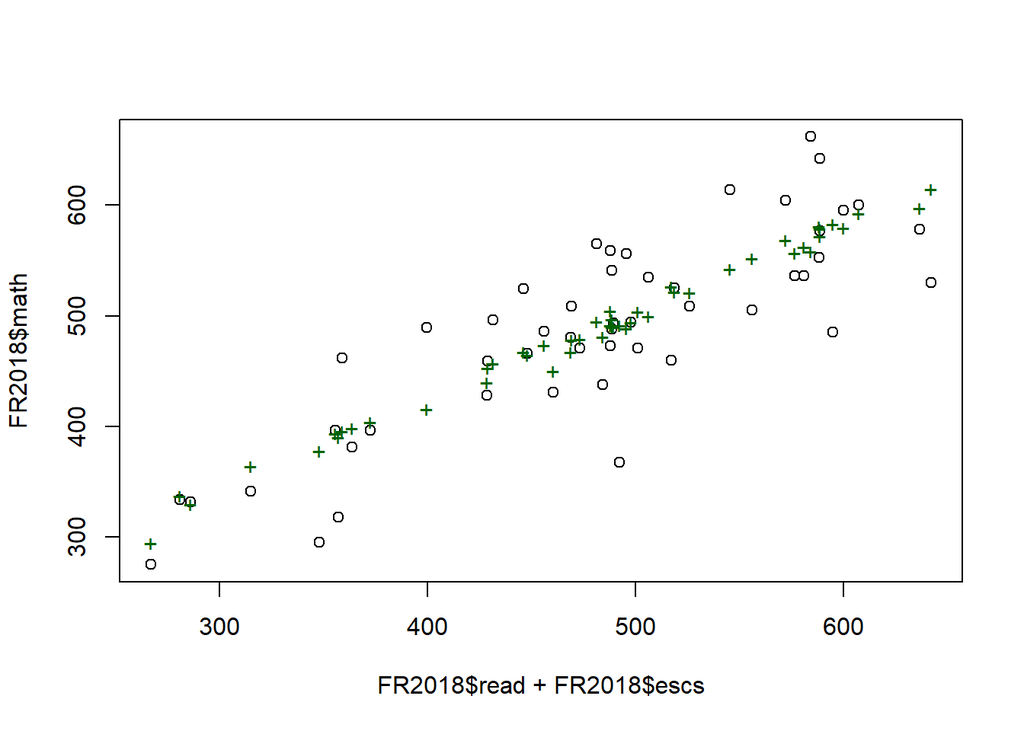

```r
> plot(FR2018$read + FR2018$escs , FR2018$math)
> points(FR2018$read + FR2018$escs , fitted.values(FRmathereadescs) , col="darkgreen" , pch="+")
```

## Question 8

Utiliser `boxplot(math ~ gender, data = FR2018)`, `shapiro.test`, `t.test`

```r
> x.fille <- FR2018$math[FR2018$gender == "female"]
> x.garcon <- FR2018$math[FR2018$gender == "male"]
```

## Question 9

Utiliser `boxplot(science ~ gender, data = FR2018)`, `shapiro.test`, `t.test`

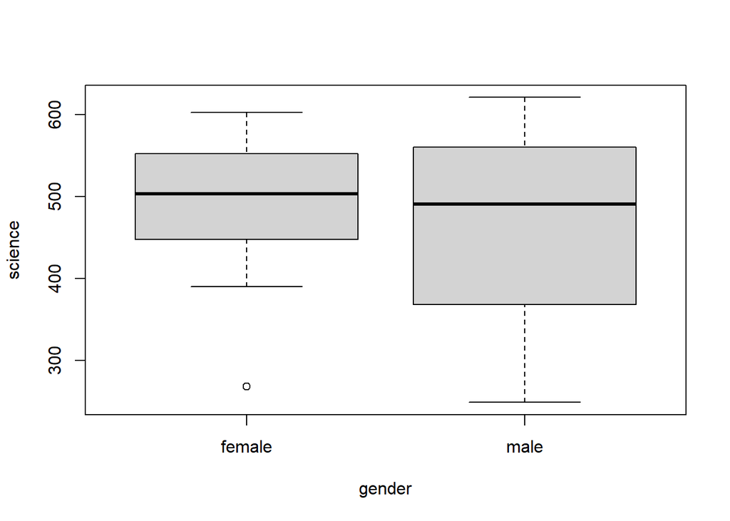

```r
> boxplot(science ~ gender, data = FR2018)
```

## Question 10

Changer `FR2018` en `PISA2018`.